# Part I - (Données PISA)

## by (James Bimbai)

## Investigation Overview

> Dans ce projet qui consistait à mener une enquête sur les comportements des élèves envers les mathématiques et aussi l'attitude des parents sur le perception de l'importance des mathématiques.

## Dataset Overview

> Nous avons travaillé sur quelques fonctionnalités ( self, gender, objective, apprehension, score, parents_view, importance, work_method) de notre ensemble de données après le processus de nettoyage.

## OBJECTIVE

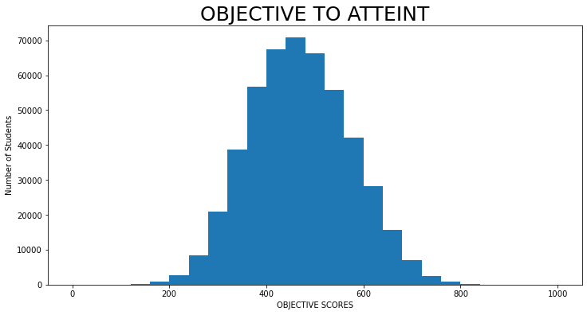

## GENDER

Le graphe nous montre que les sexes sont égaux

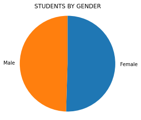

```
Male: 0.50%
Female: 0.50%
```

## COUNTRY

La marge entre d'élèves qui participent à l'enquête est entre 5 000 et 7 000. La boîte à moustaches montre également qu'il existe quelques valeurs aberrantes.

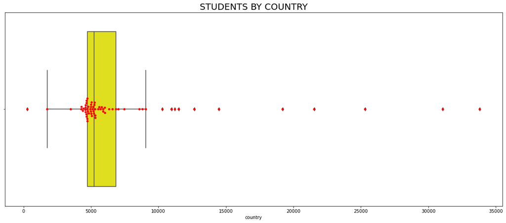

## PARENTS_VIEW

Nous avons une faible inclinaison vers la gauche, nous avons la preuve que la plupart des élèves ont une opinion positive de l'attitude de leurs parents envers les mathématiques

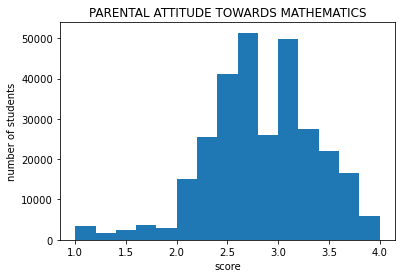

## GENDER BY STUDENT'S PERCEPTION OF PARENTAL ATTITUDE TOWARDS MATHEMATICS

Après examinations nous ne trouvons pas une grande difference entre les étudiants masculins et les étudiants féminins sur la perception des parents sur les mathématiques dans les pourcentages suivants: 25%, 50%, 75%.

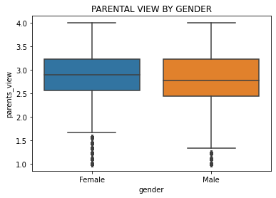

## ATTITUDE BY PARENTAL VIEW

La correction est positive et modérée de la façon dont les élèves perçoivent l'attitude des parents envers les mathématiques et la motivation de l'élève pour les mathématiques.

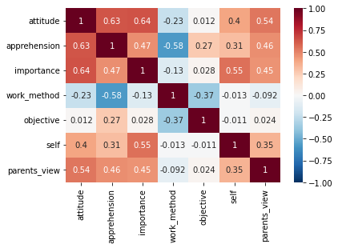

## PARENTS_VIEW

Nous avons une faible inclinaison vers la gauche, nous avons la preuve que la plupart des élèves ont une opinion positive de l'attitude de leurs parents envers les mathématiques.

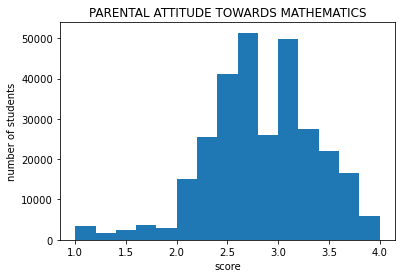

## PARENTAL_VIEW SCORE BY GENDER

Nous constatons que peu d'élèves de sexe masculin pensent que les mathématiques sont bien.

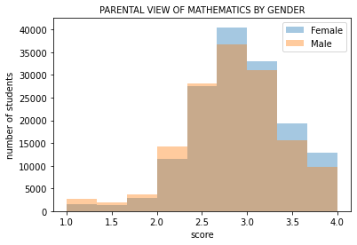

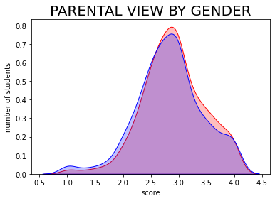

## COUNTRY

**Qusetion 3 :**

- Quel est la representation du nombres d'élèves par pays?.

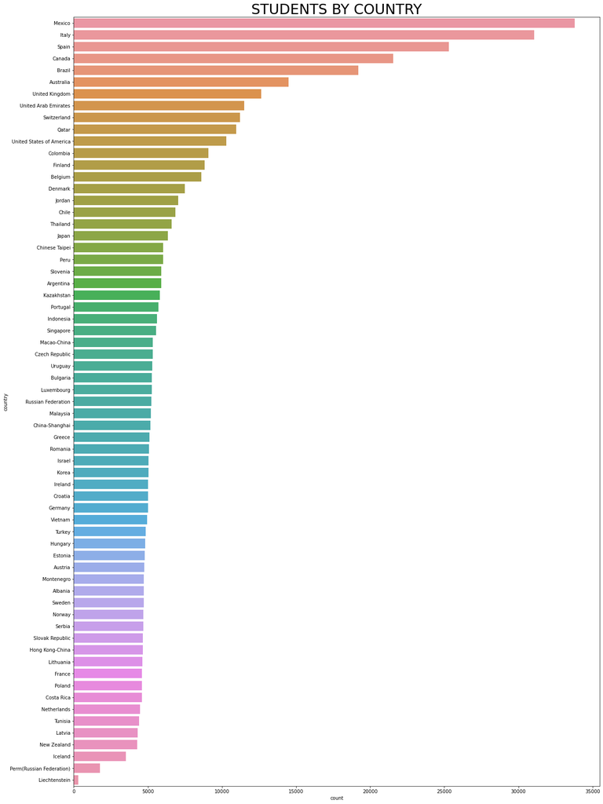